# Checkpoint 2: Building and comparing models on set-a

## 2.5 Model 2: GAM

A Logistic Generalized Additive Model (GAM) was fit with smooth terms (penalized splines, smoothness chosen by REML) on 10 continuous predictors and ICUType. The predictors are: Age, Weight, GCS_last, HR_max, Temp_min, BUN_max, WBC_max, Platelets_min, HCO3_min and Glucose_max.

Why were these predictors chosen: These 10 continuous predictors were chosen based on clinical grounds, covering age, nutrition, neurological status, heart, temperature, kidney, white cells, platelets, bicarbonate and glucose, and *most* of them were kept in all five LASSO folds.

Missing values are filled with the training-fold median, taken from the training fold only.

Per-fold AUROCs for the GAM are shown in the comparison table in Section 2.7. The mean was 0.826 (SD 0.013).

```r
gam_vars <- c("Age", "Weight", "GCS_last", "HR_max", "Temp_min",
              "BUN_max", "WBC_max", "Platelets_min", "HCO3_min", "Glucose_max")

gam_formula <- as.formula(paste("death01 ~ ICUType +",
                                paste0("s(", gam_vars, ")", collapse = " + ")))


gam_res <- lapply(1:5, function(k) {
  tr <- as.data.table(analysis(folds$splits[[k]]))
  te <- as.data.table(assessment(folds$splits[[k]]))
  tr[, death01 := as.integer(death == "1")]
  te[, death01 := as.integer(death == "1")]
  for (v in gam_vars) {                       # medians from the training fold only
    med <- median(tr[[v]], na.rm = TRUE)
    set(tr, which(is.na(tr[[v]])), v, med)
    set(te, which(is.na(te[[v]])), v, med)
  }
  fit <- mgcv::gam(gam_formula, family = binomial, data = tr, method = "REML")
  p <- as.numeric(predict(fit, newdata = te, type = "response"))
  list(oof = data.table(row_id = te$row_id, fold = k, model = "gam",
                        pred = p, death = te$death01),
       auc = as.numeric(pROC::auc(te$death01, p, levels = c(0, 1), direction = "<")))
})
gam_auc <- sapply(gam_res, `[[`, "auc")
gam_auc
c(mean = mean(gam_auc), sd = sd(gam_auc))
```

```r
gam_all <- as.data.table(d_a)
gam_all[, death01 := as.integer(death == "1")]
for (v in gam_vars)
  set(gam_all, which(is.na(gam_all[[v]])), v, median(gam_all[[v]], na.rm = TRUE))

gam_fit <- mgcv::gam(gam_formula, family = binomial, data = gam_all, method = "REML")
round(summary(gam_fit)$s.table[, c("edf", "p-value")], 3)
```

Why were these predictors chosen?

*Age:* effect might flatten or steepen at older ages and most important single risk factor in LASSO

*GCS_last:* (Glasgow Coma Score) neurological score. Low values can be a sign severe illness

*BUN_max:* kidney marker, high values are dangerous

*Platelets_min:* low counts signal bleeding or clotting problems plot could possibly non-linear

```r
or_curve <- function(var, ref) {
  x <- seq(quantile(gam_all[[var]], 0.01), quantile(gam_all[[var]], 0.99), length.out = 100)
  g <- as.data.frame(gam_all)[rep(1, length(x) + 1), ]
  g[[var]] <- c(x, ref)
  Xp  <- predict(gam_fit, newdata = g, type = "lpmatrix")
  Xd  <- sweep(Xp[-nrow(Xp), , drop = FALSE], 2, Xp[nrow(Xp), ])
  est <- as.vector(Xd %*% coef(gam_fit))
  se  <- sqrt(rowSums((Xd %*% vcov(gam_fit)) * Xd))
  data.frame(x = x, or = exp(est), lo = exp(est - 1.96 * se), hi = exp(est + 1.96 * se))
}

plot_or <- function(var, ref) {
  ggplot(or_curve(var, ref), aes(x, or)) +
    geom_ribbon(aes(ymin = lo, ymax = hi), alpha = 0.2) +
    geom_line() +
    geom_hline(yintercept = 1, linetype = "dashed") +
    scale_y_log10() +
    labs(x = var, y = "Odds ratio of death", subtitle = paste("Reference:", var, "=", ref))
}
```

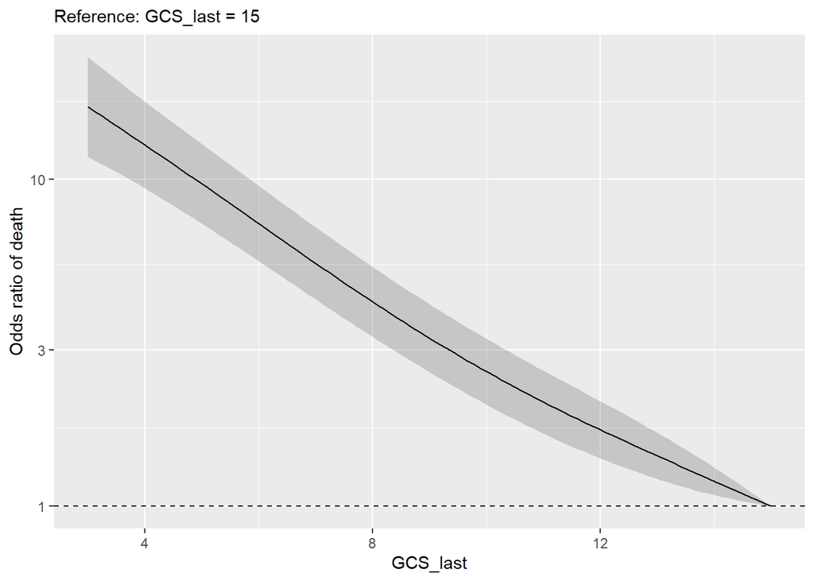

Figure 2: GAM effect of last Glasgow Coma Scale (GCS) score on the odds of death (reference GCS = 15), with 95% confidence band.

```r
plot_or("GCS_last", 15)
```

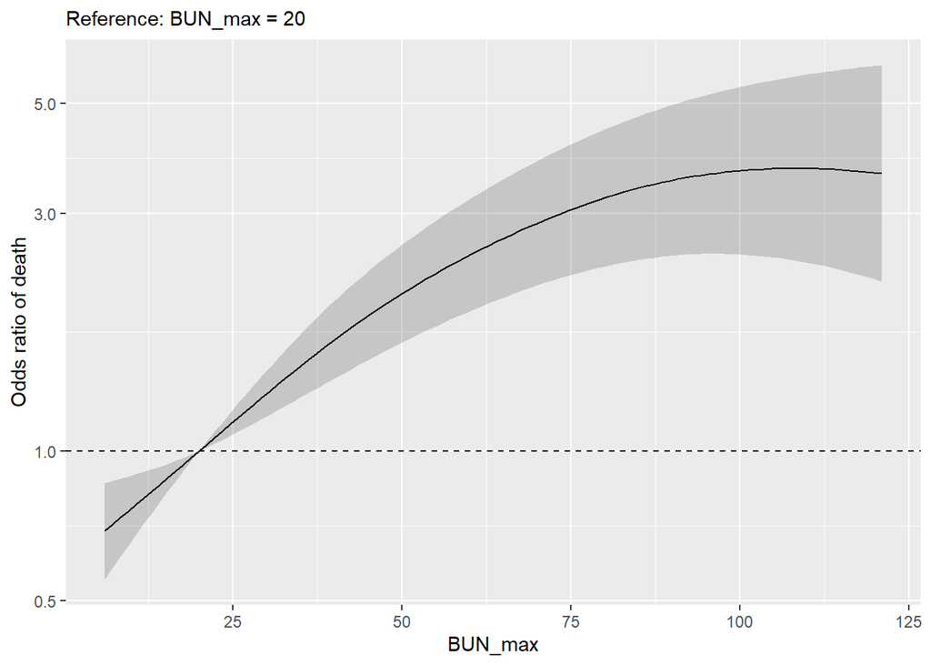

Figure 3: GAM effect of maximum blood urea nitrogen (BUN, mg/dL) on the odds of death (reference BUN = 20), with 95% confidence band.

```r
plot_or("BUN_max", 20)
```

Figure 3: is non-linear, shows that the odds of death increase with the maximum BUN. They are about 2 times those at the reference (20 mg/dL) at a BUN of 50, and they reach about 3.5 to 4 times higher by a BUN of 100. It has an edf of 2.9. This makes sense clinically, since a higher BUN indicates worse kidney function and a sicker patient.

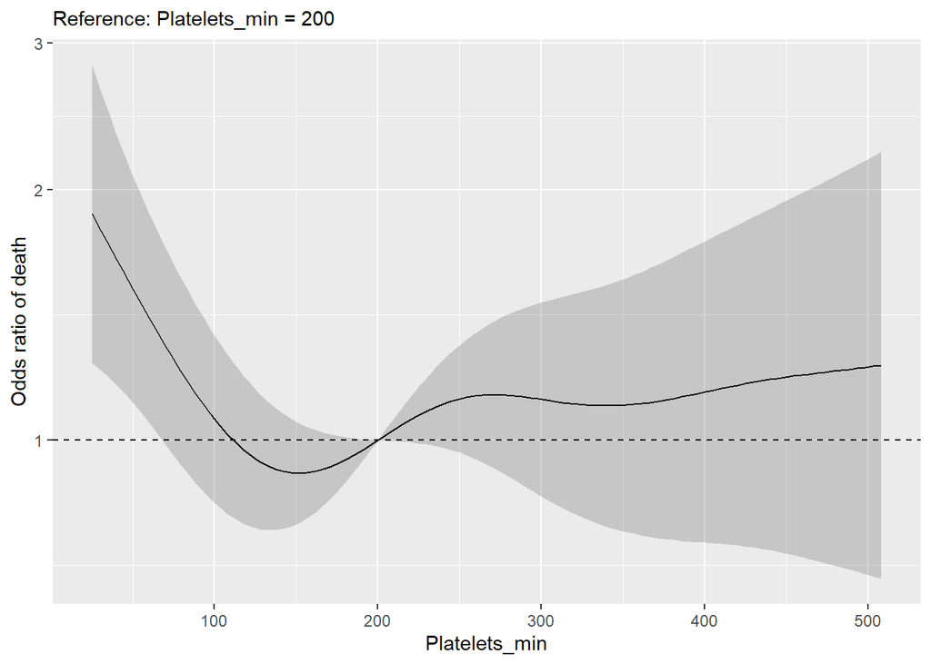

Figure 4: GAM effect of minimum platelet count (10^3/uL) on the odds of death (reference = 200), with 95% confidence band.

```r
plot_or("Platelets_min", 200)
```

Figure 4: is non-linear shows that a very low minimum platelet count is associated with higher odds of death. Has an edf of 4.5. This makes sense clinically, since a low platelet count is marker of severe illness.

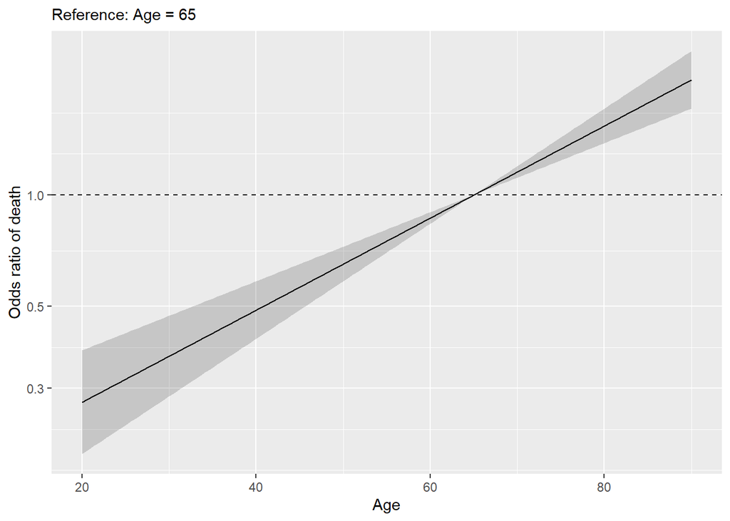

Figure 5: GAM effect of age (years) on the odds of death (reference age = 65), with 95% confidence band.

```r
plot_or("Age", 65)
```

Figure 5: linear shows that the odds of death rise steadily with age and has an edf of 1. This makes sense clinically, advancing age is a consistent predictor of in-hospital mortality.

## 2.6 Model 3: tree ensemble

Per-fold AUROCs for the random forest are shown in the comparison table in Section 2.7. The mean was 0.835 (SD 0.012)

Here a random forest (ranger, 500 trees) was used. Missing values were imputed with the training-fold median, plus the same four missingness flags. The tuning grid was mtry (predictors tried per split) in {3, 6, 10} by min_n (minimum stays per leaf) in {10, 30, 60}, which is 9 combinations. They were chosen by log loss with the same inner 5-fold CV inside each outer training set.

```r
rec_rf <- recipe(death ~ ., data = d_a) |>
  update_role(row_id, new_role = "id") |>
  step_indicate_na(MAP_min, pH_min, Bilirubin_max, Albumin_min) |>
  step_impute_median(all_numeric_predictors()) |>
  step_impute_mode(all_nominal_predictors())

rf_spec <- rand_forest(mtry = tune(), min_n = tune(), trees = 500) |>
  set_engine("ranger", seed = 707) |>
  set_mode("classification")
rf_wf   <- workflow() |> add_recipe(rec_rf) |> add_model(rf_spec)
rf_grid <- expand.grid(mtry = c(3, 6, 10), min_n = c(10, 30, 60))

rf_res <- lapply(1:5, function(k) {
  outer_split <- folds$splits[[k]]
  tuned <- tune_grid(rf_wf, resamples = inner[[k]], grid = rf_grid,
                     metrics = metric_set(mn_log_loss))
  best  <- select_best(tuned, metric = "mn_log_loss")
  fit_k <- fit(finalize_workflow(rf_wf, best), analysis(outer_split))
  pred  <- augment(fit_k, assessment(outer_split))
  list(oof = data.table(row_id = pred$row_id, fold = k, model = "rf",
                        pred = pred$.pred_1, death = as.integer(as.character(pred$death))),
       auc = roc_auc(pred, death, .pred_1)$.estimate,
       mtry = best$mtry, min_n = best$min_n)
})

rf_auc <- sapply(rf_res, `[[`, "auc")
data.table(fold = 1:5, auc = rf_auc,
           mtry = sapply(rf_res, `[[`, "mtry"), min_n = sapply(rf_res, `[[`, "min_n"))
c(mean = mean(rf_auc), sd = sd(rf_auc))
```

## 2.7 Comparison and final model

```r
auc_tab <- data.table(
  fold    = 1:5,
  SAPS_I  = bench$saps1,
  SOFA    = bench$sofa,
  LASSO   = lasso_auc,
  GAM     = gam_auc,
  Forest  = rf_auc
)
summary_tab <- rbind(auc_tab[, lapply(.SD, mean), .SDcols = !"fold"][, stat := "mean"],
                     auc_tab[, lapply(.SD, sd),   .SDcols = !"fold"][, stat := "sd"])
knitr::kable(auc_tab, digits = 3, caption = "AUROC by held-out fold")
```

AUROC by held-out fold

| fold | SAPS_I | SOFA | LASSO | GAM | Forest |
| --- | --- | --- | --- | --- | --- |
| 1 | 0.646 | 0.643 | 0.842 | 0.842 | 0.849 |
| 2 | 0.636 | 0.614 | 0.839 | 0.832 | 0.842 |
| 3 | 0.635 | 0.607 | 0.818 | 0.813 | 0.819 |
| 4 | 0.636 | 0.589 | 0.833 | 0.812 | 0.827 |
| 5 | 0.697 | 0.659 | 0.830 | 0.830 | 0.837 |

```r
knitr::kable(summary_tab, digits = 3, caption = "Mean and SD across folds")
```

Mean and SD across folds

| SAPS_I | SOFA | LASSO | GAM | Forest | stat |
| --- | --- | --- | --- | --- | --- |
| 0.650 | 0.623 | 0.832 | 0.826 | 0.835 | mean |
| 0.027 | 0.028 | 0.009 | 0.013 | 0.012 | sd |

This Table shows the means and standard deviations across all folds and that all three models outperform both benchmarks. Mean AUROC was 0.832 for the LASSO, 0.826 for the GAM and 0.835 for the random forest, compared with 0.650 for SAPS-I and 0.623 for SOFA. The three models differ by at most 0.009, within their fold-to-fold SD, so none is clearly better.

The best model beats SAPS-I and SOFA by about 0.18–0.21 AUROC, many times the fold-to-fold SD (about 0.01–0.03).

I choose LASSO as the final model because it is the simplest, linear, and has lowest SD(0.009). LASSO was refit on all of set-a and saved.

SAPS-I and SOFA are fixed scores, not fitted to this data, whereas the models were trained on it. Five folds also give only a rough estimate of the SD.

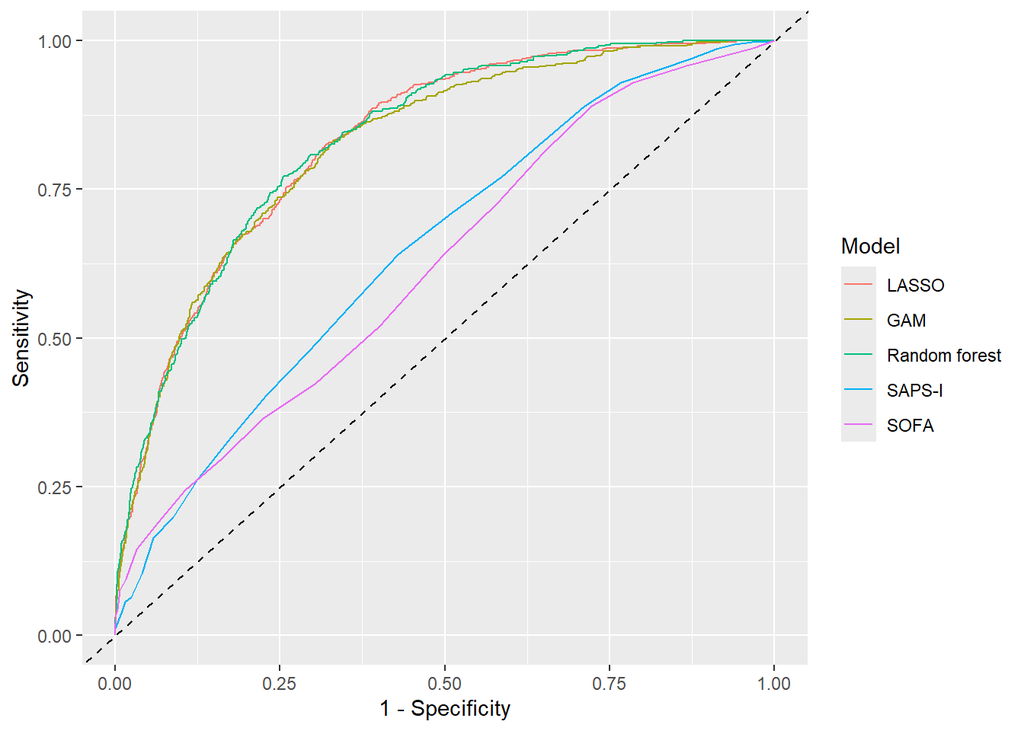

Figure 6: Out-of-fold ROC curves for the LASSO, GAM, random forest, SAPS-I and SOFA.

```r
n <- nrow(model_tab)
oof <- rbindlist(c(lapply(lasso_res, `[[`, "oof"),
                   lapply(gam_res,   `[[`, "oof"),
                   lapply(rf_res,    `[[`, "oof")))
oof <- rbind(oof,
  data.table(row_id = seq_len(n), fold = NA, model = "saps1",
             pred = model_tab$saps1, death = as.integer(model_tab$death))[!is.na(pred)],
  data.table(row_id = seq_len(n), fold = NA, model = "sofa",
             pred = model_tab$sofa,  death = as.integer(model_tab$death))[!is.na(pred)])

oof[, model := factor(model, levels = c("lasso", "gam", "rf", "saps1", "sofa"),
                      labels = c("LASSO", "GAM", "Random forest", "SAPS-I", "SOFA"))]

roc_list <- lapply(split(oof, oof$model), function(d)
  pROC::roc(d$death, d$pred, levels = c(0, 1), direction = "<", quiet = TRUE))

pROC::ggroc(roc_list, legacy.axes = TRUE) +
  geom_abline(linetype = "dashed") +
  labs(colour = "Model", x = "1 - Specificity", y = "Sensitivity")
```

Figure 6 shows that the three models (LASSO, GAM Random Forest) overlap almost everywhere on the graph and lie above the benchmarks. The three models discriminate much better than either benchmark and are indistinguishable from one another. SAPS-I is slightly above SOFA at most points, aligning with the AUROCs.

```r
saveRDS(lasso_final, file.path(out_dir, "cp2_final_model.rds"))
# fitted workflow: recipe + model

fwrite(oof, file.path(out_dir, "cp2_oof_predictions.csv"))
dir(out_dir, pattern = "cp2_")
```